# PML_Exercise

Kristen Dardia

July 15, 2017

# Peer-graded Assignment: Practical Machine Learning Assignment

# Background

### data loading

```r
setwd("H:/Desktop/R Programming/PML")
training <- read.csv("pml-training.csv")
testing  <- read.csv("pml-testing.csv")
```

### look at data

```r
dim(training)
```

```
## [1] 19622   160
```

```r
dim(testing)
```

```
## [1]  20 160
```

```r
names(training)
```

```
##   [1] "X"                        "user_name"
##   [3] "raw_timestamp_part_1"     "raw_timestamp_part_2"
##   [5] "cvtd_timestamp"           "new_window"
##   [7] "num_window"               "roll_belt"
##   [9] "pitch_belt"               "yaw_belt"
##  [11] "total_accel_belt"         "kurtosis_roll_belt"
##  [13] "kurtosis_picth_belt"      "kurtosis_yaw_belt"
##  [15] "skewness_roll_belt"       "skewness_roll_belt.1"
##  [17] "skewness_yaw_belt"        "max_roll_belt"
##  [19] "max_picth_belt"           "max_yaw_belt"
##  [21] "min_roll_belt"            "min_pitch_belt"
##  [23] "min_yaw_belt"             "amplitude_roll_belt"
##  [25] "amplitude_pitch_belt"     "amplitude_yaw_belt"
##  [27] "var_total_accel_belt"     "avg_roll_belt"
##  [29] "stddev_roll_belt"         "var_roll_belt"
```

[output cut: 65 more lines]

```r
names(testing)
```

```
##   [1] "X"                        "user_name"
##   [3] "raw_timestamp_part_1"     "raw_timestamp_part_2"
##   [5] "cvtd_timestamp"           "new_window"
##   [7] "num_window"               "roll_belt"
##   [9] "pitch_belt"               "yaw_belt"
##  [11] "total_accel_belt"         "kurtosis_roll_belt"
##  [13] "kurtosis_picth_belt"      "kurtosis_yaw_belt"
##  [15] "skewness_roll_belt"       "skewness_roll_belt.1"
##  [17] "skewness_yaw_belt"        "max_roll_belt"
##  [19] "max_picth_belt"           "max_yaw_belt"
##  [21] "min_roll_belt"            "min_pitch_belt"
##  [23] "min_yaw_belt"             "amplitude_roll_belt"
##  [25] "amplitude_pitch_belt"     "amplitude_yaw_belt"
##  [27] "var_total_accel_belt"     "avg_roll_belt"
##  [29] "stddev_roll_belt"         "var_roll_belt"
```

[output cut: 65 more lines]

### data cleaning

#### Remove useless variables

```r
badvar <- c("X", "user_name", "kurtosis_yaw_belt", "skewness_yaw_belt", "amplitude_yaw_belt", "cvtd_timestamp", "kurtosis_yaw_dumbbell", "skewness_yaw_dumbbell", "kurtosis_yaw_forearm", "skewness_yaw_forearm")

training <- training[ , -which(names(training) %in% badvar)]
```

#### convert to numeric if it should be numeric

```r
numvar <- c(
  "kurtosis_roll_belt", "kurtosis_picth_belt", "skewness_roll_belt",
  "skewness_roll_belt.1", "max_yaw_belt", "min_yaw_belt",
  "kurtosis_roll_arm","kurtosis_picth_arm", "kurtosis_yaw_arm",
  "skewness_roll_arm","skewness_pitch_arm", "skewness_yaw_arm",
  "kurtosis_roll_dumbbell", "kurtosis_picth_dumbbell","skewness_roll_dumbbell",
  "skewness_pitch_dumbbell","max_yaw_dumbbell", "min_yaw_dumbbell",
  "kurtosis_roll_forearm","kurtosis_picth_forearm", "skewness_roll_forearm",
  "skewness_pitch_forearm", "max_yaw_forearm", "min_yaw_forearm"
)
for (variable in numvar) {
  training[[variable]] <- as.numeric(as.character(training[[variable]]))
}
```

### finally, remove NA variables and try to work with just the tidy data

```r
training.naCounts <- colSums(sapply(training, is.na))
training.a <- training[,training.naCounts == 0]
```

### now do it again for testing dataset

```r
testing <- testing[ , -which(names(testing) %in% badvar)]
```

```r
for (variable in numvar) {
  testing[[variable]] <- as.numeric(as.character(testing[[variable]]))
}
```

```r
testing.naCounts <- colSums(sapply(testing, is.na))
testing.a <- testing[,testing.naCounts == 0]
```

### Cross Validation

#### partition the original data into 70% training and 30% testing.

```r
set.seed(2017)
library(caret)
inTrain <- createDataPartition(training.a$classe, p=0.7, list=FALSE )
train   <- training.a[ inTrain, ]
test    <- training.a[ -inTrain, ]
table(train$class)
```

```
##
##    A    B    C    D    E
## 3906 2658 2396 2252 2525
```

```r
table(test$class)
```

```
##
##    A    B    C    D    E
## 1674 1139 1026  964 1082
```

### now let’s fit a random forest model which is good for classification. make sure to load the caret package

Random Forest model

```r
modelFit  <- train( classe~., data=train, method="rf",importance=TRUE)
```

### now let’s see how good the model is on the holdout of the training data and also on the test data; fit first and then look at confusion matrix

```r
predTrain <- predict( modelFit, train )
predTest  <- predict( modelFit, test )
confusionMatrix( predTrain, train$classe )
```

```
## Confusion Matrix and Statistics
##
##           Reference
## Prediction    A    B    C    D    E
##          A 3906    0    0    0    0
##          B    0 2658    0    0    0
##          C    0    0 2396    0    0
##          D    0    0    0 2252    0
##          E    0    0    0    0 2525
##
## Overall Statistics
##
##                Accuracy : 1
##                  95% CI : (0.9997, 1)
##     No Information Rate : 0.2843
##     P-Value [Acc > NIR] : < 2.2e-16
##
##                   Kappa : 1
##  Mcnemar's Test P-Value : NA
##
## Statistics by Class:
##
##                      Class: A Class: B Class: C Class: D Class: E
## Sensitivity            1.0000   1.0000   1.0000   1.0000   1.0000
## Specificity            1.0000   1.0000   1.0000   1.0000   1.0000
## Pos Pred Value         1.0000   1.0000   1.0000   1.0000   1.0000
## Neg Pred Value         1.0000   1.0000   1.0000   1.0000   1.0000
## Prevalence             0.2843   0.1935   0.1744   0.1639   0.1838
## Detection Rate         0.2843   0.1935   0.1744   0.1639   0.1838
## Detection Prevalence   0.2843   0.1935   0.1744   0.1639   0.1838
## Balanced Accuracy      1.0000   1.0000   1.0000   1.0000   1.0000
```

```r
confusionMatrix( predTest, test$classe )
```

```
## Confusion Matrix and Statistics
##
##           Reference
## Prediction    A    B    C    D    E
##          A 1674    0    0    0    0
##          B    0 1139    1    0    0
##          C    0    0 1025    1    0
##          D    0    0    0  963    1
##          E    0    0    0    0 1081
##
## Overall Statistics
##
##                Accuracy : 0.9995
##                  95% CI : (0.9985, 0.9999)
##     No Information Rate : 0.2845
##     P-Value [Acc > NIR] : < 2.2e-16
##
##                   Kappa : 0.9994
##  Mcnemar's Test P-Value : NA
##
## Statistics by Class:
##
##                      Class: A Class: B Class: C Class: D Class: E
## Sensitivity            1.0000   1.0000   0.9990   0.9990   0.9991
## Specificity            1.0000   0.9998   0.9998   0.9998   1.0000
## Pos Pred Value         1.0000   0.9991   0.9990   0.9990   1.0000
## Neg Pred Value         1.0000   1.0000   0.9998   0.9998   0.9998
## Prevalence             0.2845   0.1935   0.1743   0.1638   0.1839
## Detection Rate         0.2845   0.1935   0.1742   0.1636   0.1837
## Detection Prevalence   0.2845   0.1937   0.1743   0.1638   0.1837
## Balanced Accuracy      1.0000   0.9999   0.9994   0.9994   0.9995
```

#### finally, let’s see which variables actually mattered:

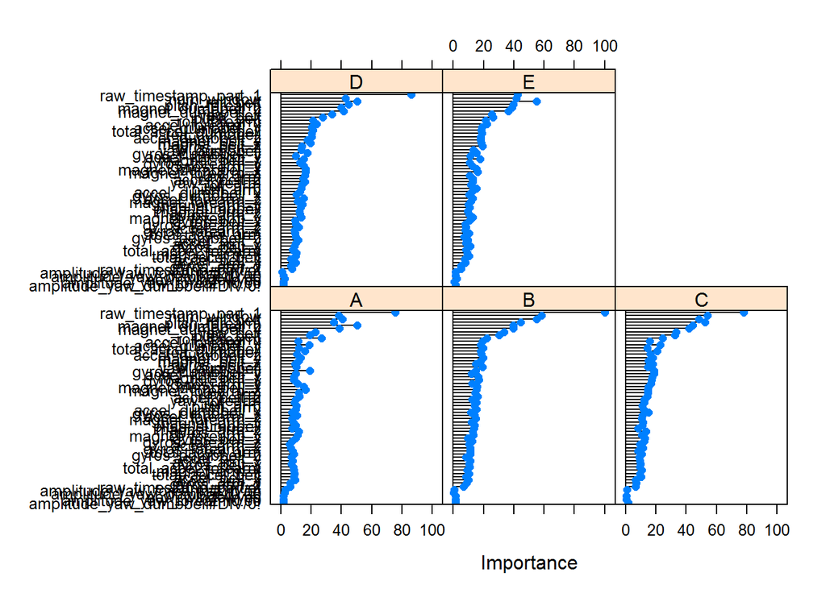

```r
variable.importances <- varImp(modelFit)
plot(variable.importances)
```

###looks like just a few mattered; next step here would be to try to limit the number of variables to cut down on processing time. That’s for another day :)